# 政治学方法論 I：欠測値を持つデータと Multiple Imputation

矢内 勇生

January 14, 2015

**mi** パッケージを利用するので、（インストール済みでないなら）インストールし、読み込む。

```r
if(!require(mi)){
  install.packages("mi", dependencies=TRUE)
}
require(mi)
```

## R における欠測値の扱い

R では欠測値（欠損値, missing values） を **NA** と表記する。 CSV 形式で記録されたデータを読み込む際、値がないところ（空欄）は自動的に NA に変換される。 また、`read.dta()` を使ってStata 形式のデータを読み込む場合、Stataの欠測である「.」 も自動的に NA に置き換えられる。 CSV などのテキスト形式やExcel などのスプレッドシートで用意されたデータセットが NA 以外の値を欠測値にもつときは、引数 `na.strings` で欠測の値を明示する必要がある。たとえば、CSV ファイル内で欠測が「.」で示されているとき、次のようにしてデータ を読み込む。

```r
height <- read.csv("data/fake-missing.csv", na.strings='.')
dim(height)
```

```
## [1] 500   4
```

このデータは、500の観測個体について4つ変数をもっていることが窺える。

ここで、`summary()` を使ってデータの中身を確認してみよう。

```r
summary(height)
```

```
##      child           sex          father          mother
##  Min.   :151.1   female:242   Min.   :154.8   Min.   :146.4
##  1st Qu.:164.0   male  :211   1st Qu.:166.8   1st Qu.:156.7
##  Median :168.5   NA's  : 47   Median :170.0   Median :159.9
##  Mean   :168.6                Mean   :170.1   Mean   :160.0
##  3rd Qu.:173.6                3rd Qu.:173.4   3rd Qu.:163.0
##  Max.   :184.1                Max.   :185.4   Max.   :174.2
##  NA's   :54                   NA's   :41      NA's   :42
```

ここから、このデータセットに含まれる4つの変数は child, sex, father, mother であることがわかる。 また、各変数には欠測値があり、その数は、54, 47, 41, 42 であることがわかる。

ここで、child の標準偏差を求めてみよう。標準偏差は`sd()` で求められるはずである。

```r
sd(height$child)
```

```
## [1] NA
```

このように、欠測値をもつ変数の統計量を求めようとすると、NA が返ってきてしまう。 欠測値以外の値を使って標準偏差を求めるには、`na.rm=TRUE` としなければならない。

```r
sd(height$child, na.rm=TRUE)
```

```
## [1] 6.680064
```

このデータセットを使って回帰分析を行ってみよう。 まず、child を応答変数、father とmother を説明変数として、OLSによる回帰分析を行う。

```r
fit.fake.1 <- lm(child ~ father + mother, data=height)
display(fit.fake.1)
```

```
## lm(formula = child ~ father + mother, data = height)
##             coef.est coef.se
## (Intercept) 93.64    15.66
## father       0.02     0.07
## mother       0.44     0.06
## ---
## n = 377, k = 3
## residual sd = 6.36, R-Squared = 0.11
```

このように、欠測値があるデータセットでも、OLS は実行できる。

しかし、結果を見ると、“n = 377” と表示されている。 データセットの “n” は 500だったはずでは？

このモデルに、sex という説明変数を追加するとどうなるだろうか。 sex の値は “male” と “female” の2通りなので、male ダミーを作ってから分析してみよう。

```r
height$male <- ifelse(height$sex=="male", 1, 0)
fit.fake.2 <- lm(child ~ father + mother + male, data=height)
display(fit.fake.2)
```

```
## lm(formula = child ~ father + mother + male, data = height)
##             coef.est coef.se
## (Intercept) 90.04    12.09
## father       0.03     0.05
## mother       0.43     0.05
## male         8.38     0.50
## ---
## n = 341, k = 4
## residual sd = 4.65, R-Squared = 0.51
```

これも一見すると無事に分析できたようだが、今度は “n = 341” になっている。なぜ？

どちらも、n が500より小さくなる理由は明らかだろう。

今度は、欠測値を「手動で」取り除いて分析する。 変数のうち1つでも欠測がある観測個体を取り除くには、`na.omit()` と使う。

```r
height.comp <- na.omit(height)
fit.fake.1m <- lm(child ~ father + mother, data=height.comp)
fit.fake.2m <- lm(child ~ father + mother + male, data=height.comp)
display(fit.fake.1m)
```

```
## lm(formula = child ~ father + mother, data = height.comp)
##             coef.est coef.se
## (Intercept) 89.28    16.29
## father       0.06     0.07
## mother       0.44     0.07
## ---
## n = 341, k = 3
## residual sd = 6.26, R-Squared = 0.11
```

```r
display(fit.fake.2m)
```

```
## lm(formula = child ~ father + mother + male, data = height.comp)
##             coef.est coef.se
## (Intercept) 90.04    12.09
## father       0.03     0.05
## mother       0.43     0.05
## male         8.38     0.50
## ---
## n = 341, k = 4
## residual sd = 4.65, R-Squared = 0.51
```

今度は、どちらも “n=341” である。 fit.fake.2m はfit.fake.2 と同じ結果だが、fit.fake.1m とfit.fake.1 の結果は異なる。

変数ごとに欠測を取り除く場合、例えば、sex が欠測の個体だけを取り除きたいなら、

```r
height.2 <- subset(height, !is.na(sex))
summary(height.2)
```

```
##      child           sex          father          mother
##  Min.   :151.1   female:242   Min.   :154.8   Min.   :146.4
##  1st Qu.:164.1   male  :211   1st Qu.:166.8   1st Qu.:156.4
##  Median :168.5                Median :170.1   Median :159.9
##  Mean   :168.5                Mean   :170.1   Mean   :159.9
##  3rd Qu.:173.6                3rd Qu.:173.5   3rd Qu.:163.0
##  Max.   :183.6                Max.   :183.5   Max.   :174.2
##  NA's   :48                   NA's   :39      NA's   :38
##       male
##  Min.   :0.0000
##  1st Qu.:0.0000
##  Median :0.0000
##  Mean   :0.4658
##  3rd Qu.:1.0000
##  Max.   :1.0000
##
```

のようにする。

## 欠測が生じるメカニズム

### データ生成過程の特定

x1, x2, x3, x4の4つの説明変数によって、yが $Y_i \sim \mathrm{N}(\beta_0 + \beta_1 x_1 + \cdots + \beta_4 x_4, \sigma^2)$ というデータ生成過程によって生み出されると仮定する。 このデータ生成過程は、

```r
dgp <- function(beta, n, sigma=4){
    ## 引数：beta = 係数の母数ベクトル
    ##       n = 観測値の数
    ##       sigma = Y の標準偏差
    ## 返り値：yとx's を含むデータフレーム
    k <- length(beta)
    data.mat <- matrix(runif(n*(k-1), -5, 5), nrow=n)
    X <- cbind(rep(1, n), data.mat)
    y <- rnorm(n, X %*% beta, sigma)
    x.header <- paste("x", 1:(k-1), sep="")
    df <- data.frame(cbind(y, data.mat))
    names(df) <- c("y", x.header)
    return(df)
}
```

という関数で表せる。

### データに欠測値がない場合

欠測値がない場合のOLS のシミュレーション。

```r
beta <- c(0.2, 1, 3, -4, 2.5)
n <- 1000
trials <- 100
results <- matrix(NA, nrow=trials, ncol=length(beta))
for(i in 1:trials){
    df <- dgp(beta, n)
    y <- as.matrix(df[,1])
    X <- as.matrix(df)
    X[,1] <- rep(1, n)
    results[i,] <- coef(lm(y ~ X + 0))
}
beta.hat <- apply(results, 2, mean)
rbind(beta, beta.hat)
```

```
##               [,1]      [,2]     [,3]      [,4]     [,5]
## beta     0.2000000 1.0000000 3.000000 -4.000000 2.500000
## beta.hat 0.1952134 0.9977141 3.001087 -3.995871 2.499435
```

### 完全に無作為な欠測 (missing completely at ranodm)

どの値が欠測になるかが完全にランダムに決まるとき、欠測のある観測個体を除外した統計的推定にはどのような問題が生じるだろうか。

```r
r <- .05  ## missing rate
results <- matrix(NA, nrow=trials, ncol=length(beta))
for(i in 1:trials){
    df <- dgp(beta, n)
    missing <- rbinom(n, 1, r)
    df[,1] <- ifelse(missing==0, df[,1], NA)
    df <- na.omit(df)
    y <- df[,1]
    X <- as.matrix(df)
    X[,1] <- rep(1, nrow(df))
    results[i,] <- coef(lm(y ~ X + 0))
}
beta.hat <- apply(results, 2, mean)
rbind(beta, beta.hat)
```

```
##               [,1]     [,2]     [,3]     [,4]     [,5]
## beta     0.2000000 1.000000 3.000000 -4.00000 2.500000
## beta.hat 0.2143283 1.001303 3.005315 -4.00844 2.508818
```

### 無作為な欠測 (missing at random)

欠測が完全にランダムではなく、**データセットに含まれる** 変数の値が欠測の確率を決めているとき、 欠測のある観測個体を除外するとどのような結果が生じるだろうか。

```r
invlogit <- function(x){
    y <- 1 / (1 + exp(-x))
    return(y)
}
results <- matrix(NA, nrow=trials, ncol=length(beta))
for(i in 1:trials){
    df <- dgp(beta, n)
    missing <- rbinom(n, 1, invlogit(-6 + 1*df$x2 -1*df$x3))
    df[,1] <- ifelse(missing==0, df[,1], NA)
    df <- na.omit(df)
    y <- df[,1]
    X <- as.matrix(df)
    X[,1] <- rep(1, nrow(df))
    results[i,] <- coef(lm(y ~ X +0))
}
beta.hat <- apply(results, 2, mean)
rbind(beta, beta.hat)
```

```
##               [,1]     [,2]     [,3]      [,4]     [,5]
## beta     0.2000000 1.000000 3.000000 -4.000000 2.500000
## beta.hat 0.2091136 1.007225 3.006226 -3.997566 2.500384
```

### 観測されない説明変数に従属する欠測

欠測になる確率とその値の両者が、データセットに含まれていない変数によって決まるとき、欠測のある観測個体を除外するとどのような結果が生じるだろうか？

```r
results <- matrix(NA, nrow=trials, ncol=length(beta)-1)
for(i in 1:trials){
    df <- dgp(beta, n)
    missing <- rbinom(n, 1, invlogit(-5 + df$x3))
    df[, 1] <- ifelse(missing==0, df[,1], NA)
    df <- na.omit(df)
    y <- df[, 1]
    ## x3が観測されないとする
    ## x3があるのはdfの第4列
    X <- as.matrix(df[,-4])
    X[,1] <- rep(1, nrow(df))
    results[i,] <- coef(lm(y ~ X + 0))
}
beta.hat <- apply(results, 2, mean)
rbind(beta[-4], beta.hat)
```

```
##              [,1]      [,2]     [,3]     [,4]
##          0.200000 1.0000000 3.000000 2.500000
## beta.hat 1.286428 0.9975774 2.985408 2.508827
```

係数だけみるとそれほど問題なさそうだが、どのような問題がある？

#### 欠測値自身が欠測の確率を決めるとき

```r
results <- matrix(NA, nrow=trials, ncol=length(beta))
for(i in 1:trials){
    df <- dgp(beta, n)
    missing <- rbinom(n, 1, invlogit(-12 + df[,1]))
    df[,1] <- ifelse(missing==0, df[,1], NA)
    df <- na.omit(df)
    y <- df[,1]
    X <- as.matrix(df)
    X[,1] <- rep(1, nrow(df))
    results[i,] <- coef(lm(y ~ X + 0))
}
beta.hat <- apply(results, 2, mean)
rbind(beta, beta.hat)
```

```
##                [,1]      [,2]     [,3]      [,4]     [,5]
## beta      0.2000000 1.0000000 3.000000 -4.000000 2.500000
## beta.hat -0.5150434 0.9588026 2.866188 -3.805221 2.382515
```

どdのような問題がある？

## 欠測値を含むデータセットの分析

### 欠測値を取り除く

欠測値があるとき、それを取り除いて分析するのは一つの手ではあるが・・・

### 欠測値を補完して分析する

Gelman and Hill (2007): Ch. 25 の内容を実行してみよう。

#### データの準備

今回使うデータは、**siswave3v4impute3.csv** である。 このデータは、http://www.stat.columbia.edu/~gelman/arm/examples/sis からダウンロードすることができる。 ダウンロードしたデータをプロジェクト内のdataフォルダに保存し、Rで読み込む。

```r
# rm(list=ls())   ## ワークスペースのオブジェクトをすべて削除する
sis <- read.csv("data/siswave3v4impute3.csv")
```

RStudioのEnvironment に表示されている通り、このデータセットは943の変数を含んでいる。 使わない変数が多いので、必要な変数を取り出し、整形を施した上で、新たなデータセットとして保存しよう。

最初に、回答者の所得 (rearn) と配偶者の所得 (tearn) という2つの変数を元に、家計所得の代理変数 earnings を作ろう。ひとまず元の変数の内容を確認する。

```r
summary(sis$rearn)
```

```
##    Min. 1st Qu.  Median    Mean 3rd Qu.    Max.
##      -9       0   11000   27240   35000 1500000
```

```r
summary(sis$tearn)
```

```
##    Min. 1st Qu.  Median    Mean 3rd Qu.    Max.
##      -9       0       0   17740   17000 2500000
```

2つの変数の基本的な統計量を確認してみると、最小値はともに-9であることがわかる。 これらの変数は「所得」であり、その値は非負（0以上）になるはずだから、これらの最小値はおかしい。 コードブックを読むと、これらの変数に与えられた-9というのは、所得の値ではなく、欠測（欠損）値を表すためのコードであることがわかる。 しかし、現在の状態では、-9も0以上の値と同じように所得の値として扱われてしまう。

欠測値をNAで置き換えよう。

```r
## 負の値をNAに置き換える関数
neg2na <- function(x){ ifelse(x < 0, NA, x) }
rearn <- neg2na(sis$rearn)
tearn <- neg2na(sis$tearn)
summary(rearn)
```

```
##    Min. 1st Qu.  Median    Mean 3rd Qu.    Max.    NA's
##       0       0   16000   30330   39000 1500000     153
```

```r
summary(tearn)
```

```
##    Min. 1st Qu.  Median    Mean 3rd Qu.    Max.    NA's
##       0       0       0   19820   21600 2500000     157
```

これで、所得の値はすべて非負になった。 `summary()` の出力により、rearn には 153個、tearn には157個の欠測値があることがわかる。

これらの2つの変数を足して、新たな変数 earnings を作り、新たなデータフレーム myd に保存しよう。

```r
myd <- data.frame(earnings = rearn + tearn)
summary(myd$earnings)
```

```
##    Min. 1st Qu.  Median    Mean 3rd Qu.    Max.    NA's
##       0    5000   28000   52610   65000 3250000     251
```

次に、人種を表す変数 race から白人ダミー変数 white を作る。 コードブックによると、1が白人なので、1以外を（NAも含めて）0にする。

```r
myd$white <- ifelse(sis$race==1, 1, 0)
myd$white[is.na(sis$race)] <- 0
```

続いて、男性ダミー male と年齢が65歳より上であることを示す over65 を作る。

```r
myd$male <- ifelse(sis$sex==1, 1, 0)
myd$over65 <- ifelse(sis$r_age>65, 1, 0)
```

同様に、他の変数にも必要な変更を加える。

```r
myd$immig <- sis$immig
myd$immig[is.na(myd$immig)] <- 0
myd$educ_r <- sis$educ_r
myd$educ_r[is.na(myd$educ_r)] <- 2.5
myd$earners <- sis$earners
myd$earners[is.na(myd$earners)] <- 1
myd$no_earners <- ifelse (myd$earners==0, 1, 0)
myd$workmos <- sis$workmos
myd$earnings[myd$workmos==0] <- 0
myd$retirement <- with(sis, neg2na(socsec) + neg2na(pension))
myd$interest <- neg2na(sis$interest)
myd$assistance <- with(sis, neg2na(unemp) + neg2na(ssi) + neg2na(welfare) + neg2na(charity))
myd$other <- with(sis, neg2na(alimony) + neg2na(giftmon))
```

0かそうでないかを示すダミー変数（0でない場合に1）を作る。

```r
is.any <- function(x){
    any.x <- ifelse(x > 0, 1, 0)
    any.x[is.na(x)] <- 0
    return(any.x)
}
myd$any.unemp <- is.any(sis$unemp)
myd$any.ssi <- is.any(sis$ssi)
myd$any.welfare <- is.any(sis$welfare)
myd$any.charity <- is.any(sis$charity)
```

いくつかの変数を変換する。

```r
myd$earnings <- myd$earnings/1000
myd$retirement <- myd$retirement/1000
myd$interest <- myd$interest/1000
myd$assistance <- myd$assistance/1000
myd$other <- myd$other/1000
myd.original <- myd
```

右に歪んだ分布をもつ変数を、「トップコード」する。

```r
## See Gelman and Hill (2007): p.534
topcode <- function(a, top){
    return(ifelse(a>top, top, a))
}
myd$workhrs.top <- topcode(sis$workhrs, 40)
myd$earnings.top <- topcode(myd$earnings, 100)
myd$retirement.top <- topcode(myd$retirement, 100)
myd$interest.top <- topcode(myd$interest, 100)
myd$assistance.top <- topcode(myd$assistance, 10)
myd$other.top <- topcode(myd$other, 10)
```

#### 欠測値を補完する

単純無作為補完。

```r
## Gelman and Hill (2007): p.534
random.imp <- function(a){
    missing <- is.na(a)        ## 欠測かどうか確かめる
    n.missing <- sum(missing)  ## 欠測値の数
    a.obs <- a[!missing]       ## 観測値の数
    imputed <- a
    ## 観測された値をランダムに選んで欠測値を補完する
    imputed[missing] <- sample(a.obs, n.missing, replace=TRUE)
    return(imputed)
}
```

観察された earning.topの分布（0は除外）。

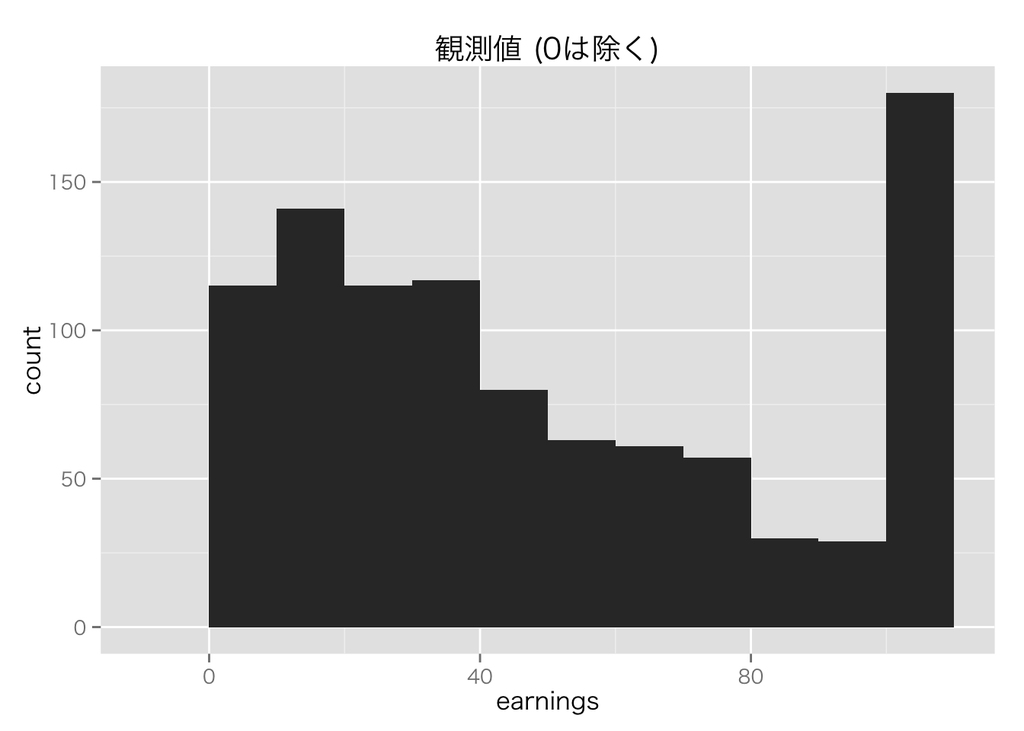

```r
require(ggplot2)
df <- subset(myd, earnings>0)
earn.obs <- ggplot(df, aes(earnings.top)) + geom_histogram(binwidth=10)
earn.obs + labs(x="earnings", title="観測値 (0は除く)")
```

上で定義した関数を使って補完する。

```r
myd$earnings.imp.1 <- random.imp(myd$earnings)
myd$earnings.imp.1 <- topcode(myd$earnings.imp.1, 100)
```

この方法で補完された earnings.top の分布

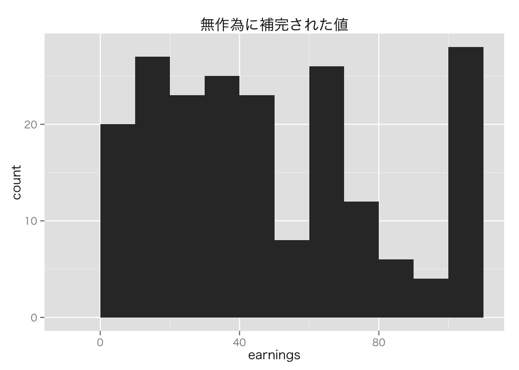

```r
df <- subset(myd, earnings.imp.1>0 & is.na(earnings))
earn.imp.1 <- ggplot(df, aes(earnings.imp.1)) + geom_histogram(binwidth=10)
earn.imp.1 + labs(x="earnings", title="無作為に補完された値")
```

回帰分析の予測値で補完。

```r
## Gelman and Hill (2007): p.534
lm.imp.2 <- lm(earnings ~ male + over65 + white + immig + educ_r +
                   workmos + workhrs.top + any.ssi + any.welfare + any.charity,
               data=myd, subset=earnings>0)
display(lm.imp.2)
```

```
## lm(formula = earnings ~ male + over65 + white + immig + educ_r +
##     workmos + workhrs.top + any.ssi + any.welfare + any.charity,
##     data = myd, subset = earnings > 0)
##             coef.est coef.se
## (Intercept) -87.02    29.61
## male         -0.36     8.79
## over65      -39.80    39.21
## white        26.03    10.18
## immig       -12.28     9.10
## educ_r       22.48     4.49
## workmos       5.33     2.06
## workhrs.top   0.79     0.62
## any.ssi     -34.39    37.31
## any.welfare -12.26    24.74
## any.charity -29.36    40.49
## ---
## n = 988, k = 11
## residual sd = 132.24, R-Squared = 0.08
```

```r
pred.2 <- predict(lm.imp.2, myd)
impute <- function(a, a.impute){
    ifelse(is.na(a), a.impute, a)
}
myd$earnings.imp.2 <- impute(myd$earnings, pred.2)
myd$earnings.imp.2.top <- topcode(myd$earnings.imp.2, 100)
```

予測値で補完された値の分布。

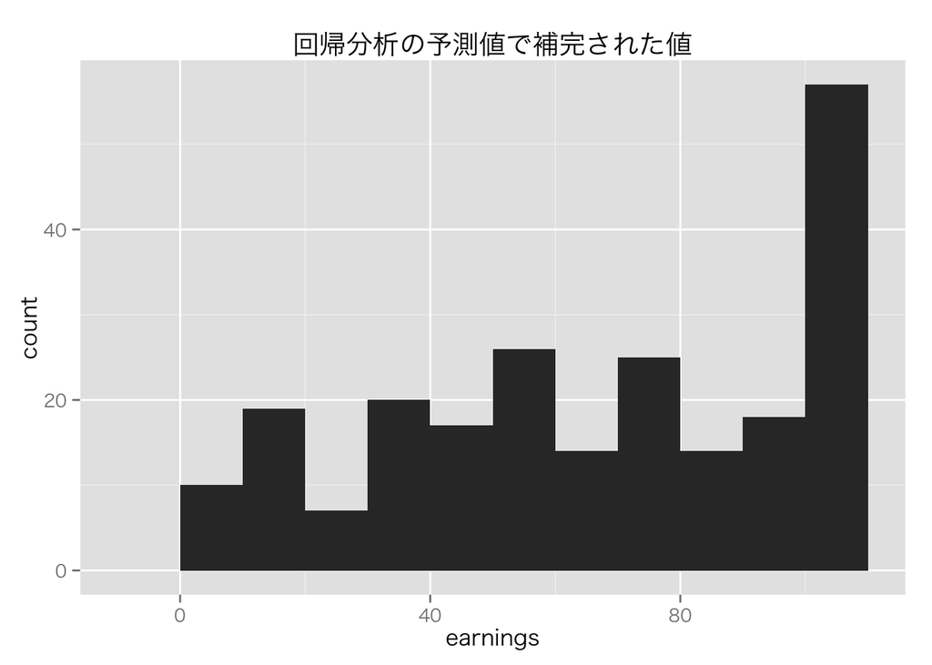

```r
df <- subset(myd, earnings.imp.2>0 & is.na(earnings))
earn.imp.2 <- ggplot(df, aes(earnings.imp.2.top)) + geom_histogram(binwidth=10)
earn.imp.2 + labs(x="earnings", title="回帰分析の予測値で補完された値")
```

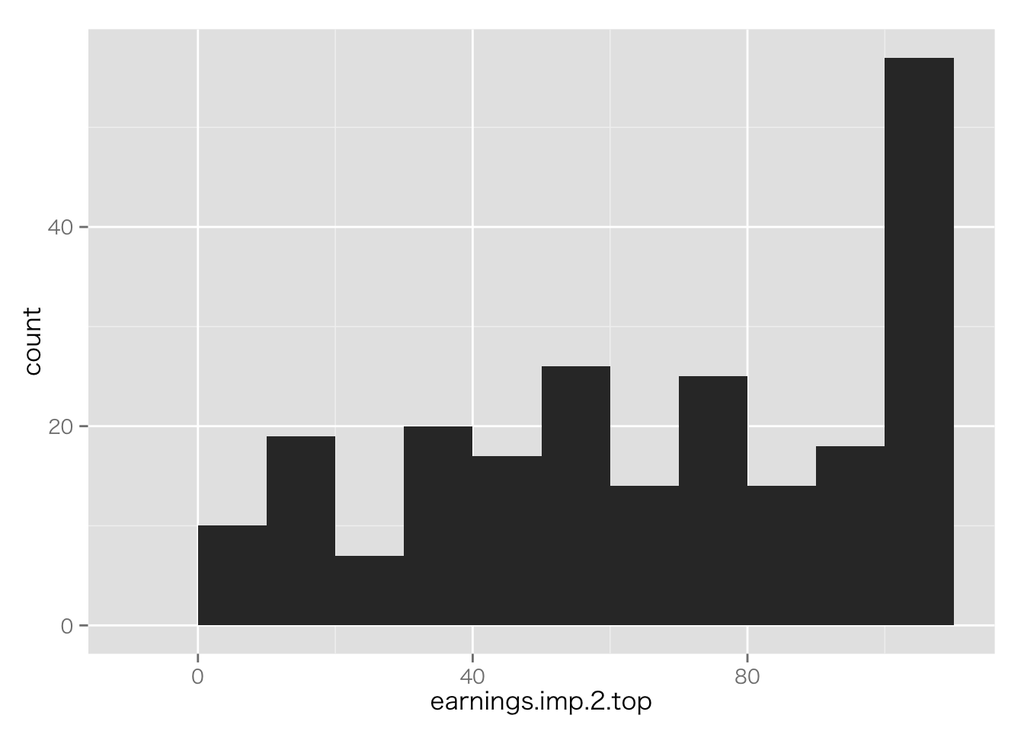

```r
print(earn.imp.2)
```

さらに改良。

```r
## Gelman and Hill (2007): p.535
lm.imp.3.sqrt <- lm(I(sqrt(earnings.top)) ~ male + over65 + white +
                        immig + educ_r + workmos + workhrs.top + any.ssi + any.welfare +
                        any.charity, data=myd, subset=earnings > 0)
display(lm.imp.3.sqrt)
```

```
## lm(formula = I(sqrt(earnings.top)) ~ male + over65 + white +
##     immig + educ_r + workmos + workhrs.top + any.ssi + any.welfare +
##     any.charity, data = myd, subset = earnings > 0)
##             coef.est coef.se
## (Intercept) -1.67     0.44
## male         0.32     0.13
## over65      -1.44     0.58
## white        0.96     0.15
## immig       -0.62     0.14
## educ_r       0.79     0.07
## workmos      0.33     0.03
## workhrs.top  0.06     0.01
## any.ssi     -0.97     0.55
## any.welfare -1.35     0.37
## any.charity -1.17     0.60
## ---
## n = 988, k = 11
## residual sd = 1.96, R-Squared = 0.44
```

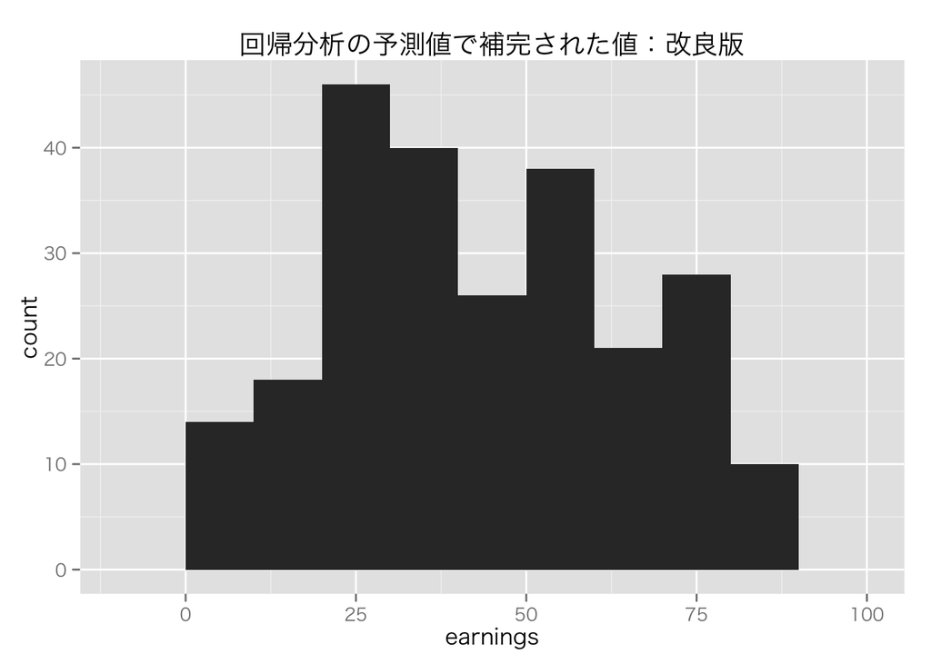

```r
pred.3.sqrt <- predict(lm.imp.3.sqrt, myd)
myd$pred.3 <- topcode(pred.3.sqrt^2, 100)
myd$earnings.imp.3 <- impute(myd$earnings.top, myd$pred.3)
df <- subset(myd, earnings.imp.3>0 & is.na(earnings))
earn.imp.3 <- ggplot(df, aes(earnings.imp.3)) + geom_histogram(binwidth=10)
earn.imp.3 + labs(x="earnings", title="回帰分析の予測値で補完された値：改良版")
```

回帰分析の予測値に不確実性を加えて補完する。

```r
## Gelman and Hill (2007): p.536
pred.4.sqrt <- rnorm(nrow(myd), predict(lm.imp.3.sqrt, myd),
                     sigma.hat(lm.imp.3.sqrt))
myd$pred.4 <- topcode(pred.4.sqrt^2, 100)
myd$earnings.imp.4 <- impute(myd$earnings.top, myd$pred.4)
```

補完された変数の比較：回帰分析の予測値 vs. 観測地からの無作為抽出

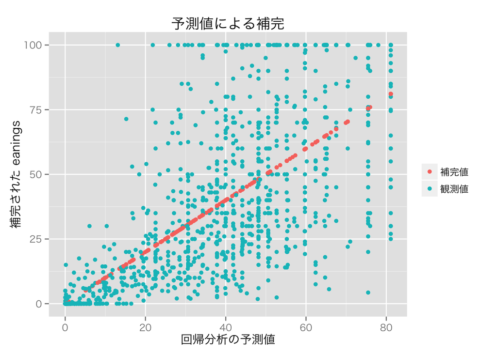

```r
reg.det <- ggplot(myd, aes(x=pred.3, y=earnings.imp.3, color=!is.na(earnings))) +
    geom_point() + scale_color_discrete(name="", labels=c("補完値", "観測値"))
reg.det + labs(x="回帰分析の予測値", y="補完された eanings", title="予測値による補完")
```

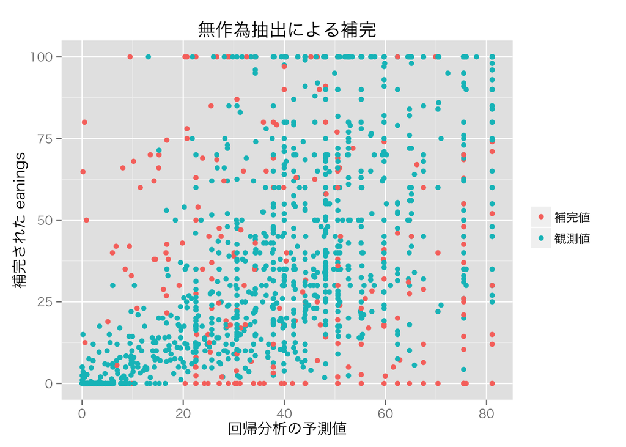

```r
reg.rnd <- ggplot(myd, aes(x=pred.3, y=earnings.imp.1, color=!is.na(earnings))) +
    geom_point() + scale_color_discrete(name="", labels=c("補完値", "観測値"))
    reg.rnd + labs(x="回帰分析の予測値", y="補完された eanings", title="無作為抽出による補完")
```

### Multiple Imputation

Multiple imputaton を用いた分析の実行手順

1. 欠測値の補完をM 回行う：各補完に使うモデルを少しずつ変える
2. 補完された書くデータを使って分析を行う $\times M$ 回
3. M個の分析結果をまとめる
   - 係数の推定値 b は、m個の分析の平均値 $b=\frac{1}{M}\sum_{i=1}^M \hat{\beta}_m$
   - 係数の標準誤差 $\mathrm{se}(b)$ は、 $\mathrm{se}(b) = \sqrt{W + \left( 1 + \frac{1}{M}\right)B}$
     - $W=\frac{1}{M}\sum_{i=1}^M s_m^2$：１つひとつのデータセット内のばらつき
     - $s_m$：$\hat{\beta}_m$ の標準誤差
     - $B = \frac{1}{M - 1}\sum_{m=1}^M(\hat{\beta}_m - b)^2$：デッタセット間のばらつき

### mi パッケージによるmultiple imputation

ここでは、基本的な使用法を説明する。 詳細については [Su, Gelman, Hill, and Yajima 2011](http://academiccommons.columbia.edu/catalog/ac:154731) を参照。

まず、パッケージを読み込む。

```r
require(mi)
```

パッケージを読み込んだら、欠測値を視覚化する。

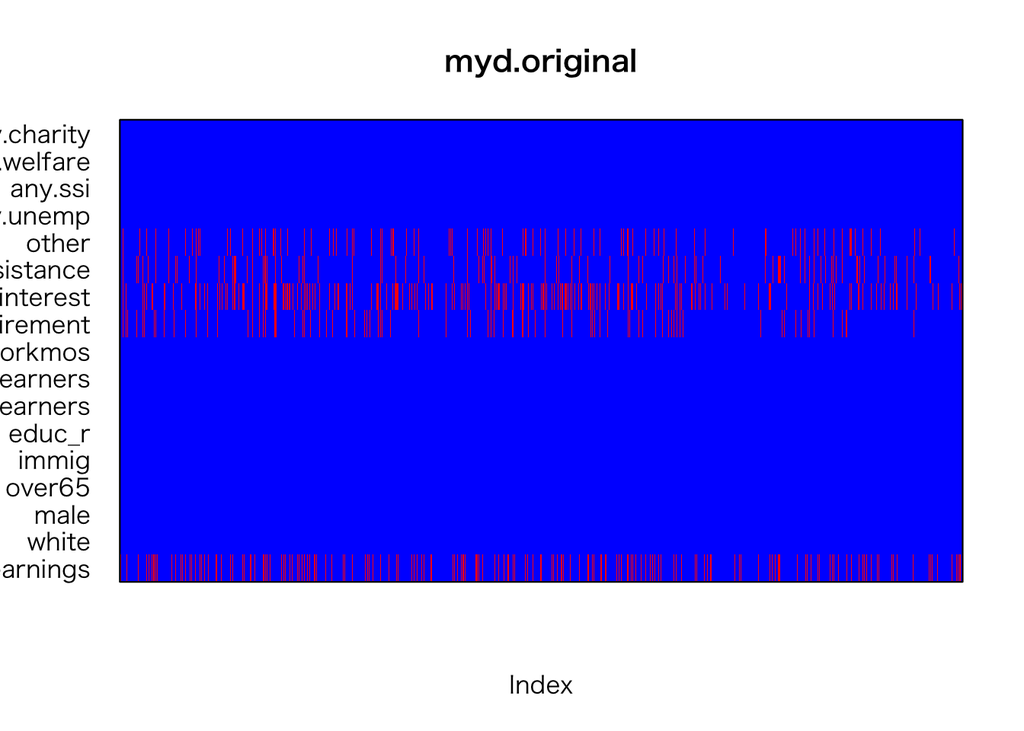

```r
mp.plot(myd.original, clustered=FALSE)
```

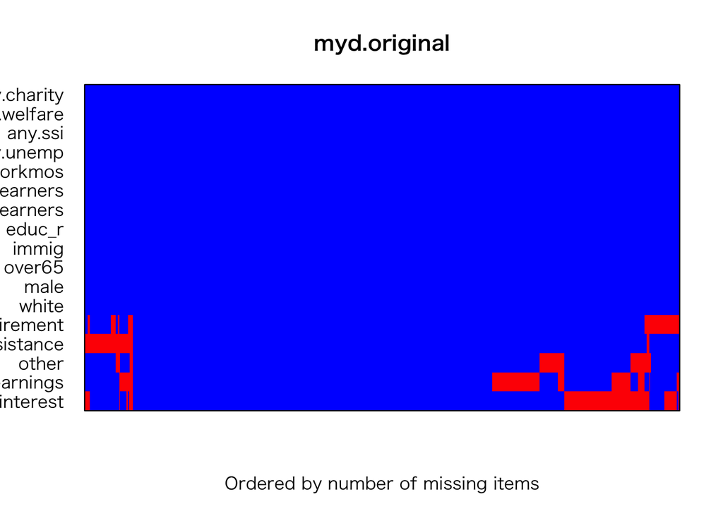

```r
mp.plot(myd.original, y.order=TRUE, x.order=TRUE, clustered=TRUE)
```

次に、`mi.info()` でデータセットの情報を確認する。

```r
myd.info <- mi.info(myd.original)
myd.info
```

```
##          names include order number.mis all.mis                type
## 1     earnings     Yes     1        241      No         nonnegative
## 2        white     Yes    NA          0      No              binary
## 3         male     Yes    NA          0      No              binary
## 4       over65     Yes    NA          0      No              binary
## 5        immig     Yes    NA          0      No              binary
## 6       educ_r     Yes    NA          0      No ordered-categorical
## 7      earners     Yes    NA          0      No ordered-categorical
## 8   no_earners     Yes    NA          0      No              binary
## 9      workmos     Yes    NA          0      No         nonnegative
## 10  retirement     Yes     2        123      No         nonnegative
## 11    interest     Yes     3        276      No         nonnegative
## 12  assistance     Yes     4        128      No         nonnegative
## 13       other     Yes     5        133      No         nonnegative
## 14   any.unemp     Yes    NA          0      No              binary
```

[output cut: 21 more lines]

このように、`mi.info()` はそれぞれの変数の名前や型 (type) の他に、imputation にその変数を含めるかどうか (include) などを規定する。この *info* の中身は `update` で変更できる。 たとえば、no_earners という変数をimputation過程から除外したいなら、

```r
myd.info <- update(myd.info, "include", list("no_earners"=FALSE))
myd.info
```

```
##          names include order number.mis all.mis                type
## 1     earnings     Yes     1        241      No         nonnegative
## 2        white     Yes    NA          0      No              binary
## 3         male     Yes    NA          0      No              binary
## 4       over65     Yes    NA          0      No              binary
## 5        immig     Yes    NA          0      No              binary
## 6       educ_r     Yes    NA          0      No ordered-categorical
## 7      earners     Yes    NA          0      No ordered-categorical
## 8   no_earners      No    NA          0      No              binary
## 9      workmos     Yes    NA          0      No         nonnegative
## 10  retirement     Yes     2        123      No         nonnegative
## 11    interest     Yes     3        276      No         nonnegative
## 12  assistance     Yes     4        128      No         nonnegative
## 13       other     Yes     5        133      No         nonnegative
## 14   any.unemp     Yes    NA          0      No              binary
```

[output cut: 21 more lines]

とすればよい。

変数の型が間違っているときも同様の変更を加える。 miでの変数型は、

1. fixed：定数
2. binary：二値変数
3. ordered-categorical：順序変数
4. unordered-categorical：順序のないカテゴリ変数
5. proportion：割合 in (0, 1), 0と１は含まない
6. positive-continuous：常に正で5つ以上の異なる値をもつもの, 0は含まない
7. nonnegative: 常に非負で5つ以上の異なる値をもつもの
8. continuous：連続値
9. log-continuous：Su et al. (2011) を参照
10. count：回数
11. predictive-mean-matching：Su et al. (2011) を参照

の11種類である。 欠測がある変数の型を指定することによって、意図しない値が補完されることを防ぐことができる。 たとえば、nonnegative を指定すれば、0未満の値が補完されることはない。

ただし、nonnegative, positive-continuous, proportion という、連続値ではあるがあるが単なるcontinuous でない変数を扱うときは、適切な変数変換を施した上でimputation を行う必要がある。 これを、`mi.preprocess()` で行う。

```r
myd.new <- mi.preprocess(myd.original)
attr(myd.new, "mi.info")
```

```
##                names include order number.mis all.mis                type
## 1    earnings.mi.log     Yes     1        513      No      log-continuous
## 2              white     Yes    NA          0      No              binary
## 3               male     Yes    NA          0      No              binary
## 4             over65     Yes    NA          0      No              binary
## 5              immig     Yes    NA          0      No              binary
## 6             educ_r     Yes    NA          0      No ordered-categorical
## 7            earners     Yes    NA          0      No ordered-categorical
## 8         no_earners     Yes    NA          0      No              binary
## 9     workmos.mi.log     Yes     2        272      No      log-continuous
## 10 retirement.mi.log     Yes     3       1374      No      log-continuous
## 11   interest.mi.log     Yes     4       1255      No      log-continuous
## 12 assistance.mi.log     Yes     5       1324      No      log-continuous
## 13      other.mi.log     Yes     6       1156      No      log-continuous
## 14         any.unemp     Yes    NA          0      No              binary
```

[output cut: 33 more lines]

このデータセットに対してmupltiple imputation を行う。 ここでは、作るデータセットの数 (n.imp) を5（多ければ多いほどよい、default=3)、繰り返しの回数 (n.iter) を30にしてみよう。

```r
IMP <- mi(myd.new, n.imp=5, n.iter=30)
```

[output not shown]

[output cut: 279 more lines]

値が収斂していないときは、続きからさらにimpute する。

```r
IMP <- mi(IMP, n.iter=20)
```

[output not shown]

[output cut: 96 more lines]

補完がきちんと行えたかどうかを視覚的に確かめるには、`plot(IMP)` とする。

補完されたデータを使って分析を行うには、`lm.mi()` や `glm.mi()` を使う。 これらの関数を使うと、結果を自動でまとめてくれる。

```r
fit <- lm.mi(earnings ~ white + male, IMP)
display(fit)
```

```
## =======================================
## Separate Estimates for each Imputation
## =======================================
##
## ** Chain 1 **
## lm(formula = formula, data = mi.data[[i]])
##             coef.est coef.se
## (Intercept) 39.87     4.23
## white       38.73     6.45
## male         4.34     6.25
## ---
## n = 1501, k = 3
## residual sd = 116.27, R-Squared = 0.02
##
## ** Chain 2 **
## lm(formula = formula, data = mi.data[[i]])
##             coef.est coef.se
## (Intercept) 38.87     4.49
## white       45.95     6.85
## male         5.41     6.64
## ---
## n = 1501, k = 3
## residual sd = 123.52, R-Squared = 0.03
##
## ** Chain 3 **
## lm(formula = formula, data = mi.data[[i]])
##             coef.est coef.se
## (Intercept) 40.74     4.27
## white       39.37     6.51
## male         3.35     6.32
## ---
## n = 1501, k = 3
## residual sd = 117.45, R-Squared = 0.02
##
## ** Chain 4 **
## lm(formula = formula, data = mi.data[[i]])
##             coef.est coef.se
## (Intercept) 40.53     4.26
## white       39.81     6.49
## male         4.68     6.29
```

[output cut: 8 more lines]

```
## white       42.97     6.99
## male         4.35     6.78
## ---
## n = 1501, k = 3
## residual sd = 126.09, R-Squared = 0.03
##
## =======================================
## Pooled Estimates
## =======================================
## lm.mi(formula = earnings ~ white + male, mi.object = IMP)
##             coef.est coef.se
## (Intercept) 40.28     4.49
## white       41.37     7.45
## male         4.43     6.51
## ---
```

補完された1つひとつのデータセットを使って分析を行いたいときは、

```r
IMP.1 <- mi.data.frame(IMP, m=1)
IMP.2 <- mi.data.frame(IMP, m=2)
IMP.3 <- mi.data.frame(IMP, m=3)
IMP.4 <- mi.data.frame(IMP, m=4)
IMP.5 <- mi.data.frame(IMP, m=5)
```

としてデータセットを取り出し、それぞれについて分析を行う。

あるいは、

```r
IMP.comp <- mi.completed(IMP)
```

でまとめて取り出せる。

最後に結果をまとめる（データセット間のばらつきを考慮に入れる）のを忘れないように。

### Reference

Gelman, Andrew, and Jennifer Hill. 2007. *Data Analysis Using Regression & Multilevel/Hierarchical Models.* New York. Cambridge University Press.